# TO 404 Homework #2

Brian Zhao

11/8/2020

### Load Libraries

```r
# Load ggplot
library("ggplot2")
# Load dplyr
library("dplyr")
```

## Homework 2

Analyzing 2019 NYC CitiBike data

### Read Data

```r
# Read Individual Data Sets
citi01 <- read.csv("201901-citibike-tripdata.csv")
citi02 <- read.csv("201902-citibike-tripdata.csv")
citi03 <- read.csv("201903-citibike-tripdata.csv")
citi04 <- read.csv("201904-citibike-tripdata.csv")
citi05 <- read.csv("201905-citibike-tripdata.csv")
citi06 <- read.csv("201906-citibike-tripdata.csv")
citi07 <- read.csv("201907-citibike-tripdata.csv")
citi08 <- read.csv("201908-citibike-tripdata.csv")
citi09 <- read.csv("201909-citibike-tripdata.csv")
citi10 <- read.csv("201910-citibike-tripdata.csv")
citi11 <- read.csv("201911-citibike-tripdata.csv")
citi12 <- read.csv("201912-citibike-tripdata.csv")

# Create combined 2019 year data set
citi_2019 <- rbind(citi01, citi02, citi03, citi04, citi05, citi06,
                  citi07, citi08, citi09, citi10, citi11, citi12)
```

### Explore Data

```r
str(citi_2019)
head(citi_2019)
tail(citi_2019)
summary(citi_2019)
```

### Clean Data

```r
# Calculate 5% Sample
citi_sample_temp <- sample_frac(citi_2019, 0.05)

# Write new sample CSV
write.csv(x = citi_sample_temp, file = "citi_sample.csv")
```

```r
# Read from new sample CSV for efficiency
citi_sample <- read.csv("citi_sample.csv")
```

```r
# Convert Factor Types
citi_sample$starttime <- as.Date(citi_sample$starttime)
citi_sample$stoptime <- as.Date(citi_sample$stoptime)
citi_sample$start.station.id <- as.factor(citi_sample$start.station.id)
citi_sample$start.station.name <- as.factor(citi_sample$start.station.name)
citi_sample$end.station.id <- as.factor(citi_sample$end.station.id)
citi_sample$end.station.name <- as.factor(citi_sample$end.station.name)
citi_sample$bikeid <- as.factor(citi_sample$bikeid) # converted to factor because each bike is unique
citi_sample$usertype <- as.factor(citi_sample$usertype)
citi_sample$gender <- as.factor(citi_sample$gender) # converted to factor because 1 = male & 2 = female
```

```r
# Re-Check str and summary
str(citi_sample)
```

```
## 'data.frame':    1027585 obs. of  16 variables:
##  $ X                      : int  1 2 3 4 5 6 7 8 9 10 ...
##  $ tripduration           : int  593 211 376 621 1621 771 422 999 1769 1949 ...
##  $ starttime              : Date, format: "2019-06-04" "2019-02-22" ...
##  $ stoptime               : Date, format: "2019-06-04" "2019-02-22" ...
##  $ start.station.id       : Factor w/ 927 levels "116","119","120",..: 154 238 18 20 73 612 231 606 303 52 ...
##  $ start.station.name     : Factor w/ 929 levels "1 Ave & E 110 St",..: 641 791 602 928 504 496 396 554 723 653 ...
##  $ start.station.latitude : num  40.7 40.7 40.7 40.7 40.8 ...
##  $ start.station.longitude: num  -74 -74 -74 -74 -74 ...
##  $ end.station.id         : Factor w/ 937 levels "116","119","120",..: 871 717 609 423 206 875 817 769 894 904 ...
##  $ end.station.name       : Factor w/ 939 levels "1 Ave & E 110 St",..: 512 799 682 594 259 381 193 264 871 127 ...
##  $ end.station.latitude   : num  40.7 40.7 40.7 40.7 40.8 ...
##  $ end.station.longitude  : num  -74 -74 -74 -73.9 -74 ...
##  $ bikeid                 : Factor w/ 19422 levels "14529","14530",..: 2734 14161 2289 13792 10579 11778 7824 12229 6493 6840 ...
##  $ usertype               : Factor w/ 2 levels "Customer","Subscriber": 2 2 2 2 1 2 2 1 1 1 ...
##  $ birth.year             : int  1978 1966 1994 1989 1967 1977 1993 1990 1969 1984 ...
##  $ gender                 : Factor w/ 3 levels "0","1","2": 2 2 2 3 2 2 2 2 1 3 ...
```

```r
summary(citi_sample)
```

```
##        X            tripduration         starttime
##  Min.   :      1   Min.   :     61.0   Min.   :2019-01-01
##  1st Qu.: 256897   1st Qu.:    363.0   1st Qu.:2019-05-02
##  Median : 513793   Median :    616.0   Median :2019-07-17
##  Mean   : 513793   Mean   :    976.7   Mean   :2019-07-11
##  3rd Qu.: 770689   3rd Qu.:   1080.0   3rd Qu.:2019-09-23
##  Max.   :1027585   Max.   :2673420.0   Max.   :2019-12-31
##
##     stoptime          start.station.id             start.station.name
##  Min.   :2019-01-01   519    :  7808   Pershing Square North:  7808
##  1st Qu.:2019-05-02   497    :  6221   E 17 St & Broadway   :  6221
##  Median :2019-07-17   3255   :  5924   8 Ave & W 31 St      :  5924
##  Mean   :2019-07-11   402    :  5676   Broadway & E 22 St   :  5676
##  3rd Qu.:2019-09-23   285    :  5637   Broadway & E 14 St   :  5637
##  Max.   :2020-01-11   435    :  5486   W 21 St & 6 Ave      :  5486
##                       (Other):990833   (Other)              :990833
##  start.station.latitude start.station.longitude end.station.id
##  Min.   :40.66          Min.   :-74.03          519    :  7741
##  1st Qu.:40.72          1st Qu.:-74.00          402    :  6268
##  Median :40.74          Median :-73.99          497    :  6238
##  Mean   :40.74          Mean   :-73.98          3255   :  6170
##  3rd Qu.:40.76          3rd Qu.:-73.97          426    :  5829
##  Max.   :40.87          Max.   :-73.88          285    :  5644
##                                                 (Other):989695
##               end.station.name  end.station.latitude end.station.longitude
##  Pershing Square North:  7741   Min.   :40.66        Min.   :-74.06
##  Broadway & E 22 St   :  6268   1st Qu.:40.72        1st Qu.:-74.00
##  E 17 St & Broadway   :  6238   Median :40.74        Median :-73.99
##  8 Ave & W 31 St      :  6170   Mean   :40.74        Mean   :-73.98
##  West St & Chambers St:  5829   3rd Qu.:40.76        3rd Qu.:-73.97
##  Broadway & E 14 St   :  5644   Max.   :40.87        Max.   :-73.88
##  (Other)              :989695
##      bikeid              usertype        birth.year   gender
##  34969  :    180   Customer  :144091   Min.   :1874   0: 77958
##  33800  :    177   Subscriber:883494   1st Qu.:1970   1:702279
##  33870  :    176                       Median :1983   2:247348
##  34026  :    174                       Mean   :1980
##  35194  :    174                       3rd Qu.:1990
##  33758  :    170                       Max.   :2003
##  (Other):1026534
```

## Part 1: Understanding the Data

Explore the data set to calculate descriptive statistics. Do exploratory visualization to better understand the data set.

### Descriptive Statistics

**Average and Median Trip Duration**

```r
# Average
mean(citi_sample$tripduration)
```

```
## [1] 976.6982
```

```r
# Median
median(citi_sample$tripduration)
```

```
## [1] 616
```

The average trip lasts a little over 16 minutes, but the median trip duration is only around 10 minutes (there are likely long trips that are skewing the data)

**Average and Median Rider Birth Year**

```r
# Average
mean(citi_sample$birth.year)
```

```
## [1] 1980.21
```

```r
# Median
median(citi_sample$birth.year)
```

```
## [1] 1983
```

The average rider is ~39 years old

**Number of Bikes in The Sample**

```r
length(levels(citi_sample$bikeid))
```

```
## [1] 19422
```

**Percent Customer vs. Subscriber**

```r
# Number of Customers in Sample
numCustomers <- nrow(citi_sample[citi_sample$usertype == "Customer", ])
# Number of Subscribers in Sample
numSubscribers <- nrow(citi_sample[citi_sample$usertype == "Subscriber", ])
# Total Users in Sample
totalUsers <- numCustomers + numSubscribers
```

14.022295% of Users are Customers 85.977705% of Users are Subscribers

**Percent Male/Female**

```r
# Number of Males in Sample
numMale <- nrow(citi_sample[citi_sample$gender == "1", ])
# Number of Females in Sample
numFemale <- nrow(citi_sample[citi_sample$gender == "2", ])
# Total People in Sample
totalPeople <- numCustomers + numSubscribers
```

68.3426675% of Riders are Male 24.0708068% of Riders are Female

**Number of Stations in Sample (Start and End)**

```r
# Start Stations
length(levels(citi_sample$start.station.name))
```

```
## [1] 929
```

```r
# End Stations
length(levels(citi_sample$end.station.name))
```

```
## [1] 939
```

Discrepancy in number of start and stop stations likely caused by variance caused by random sample

### Exploratory Visualization

**Average Trip Duration by Start Station**

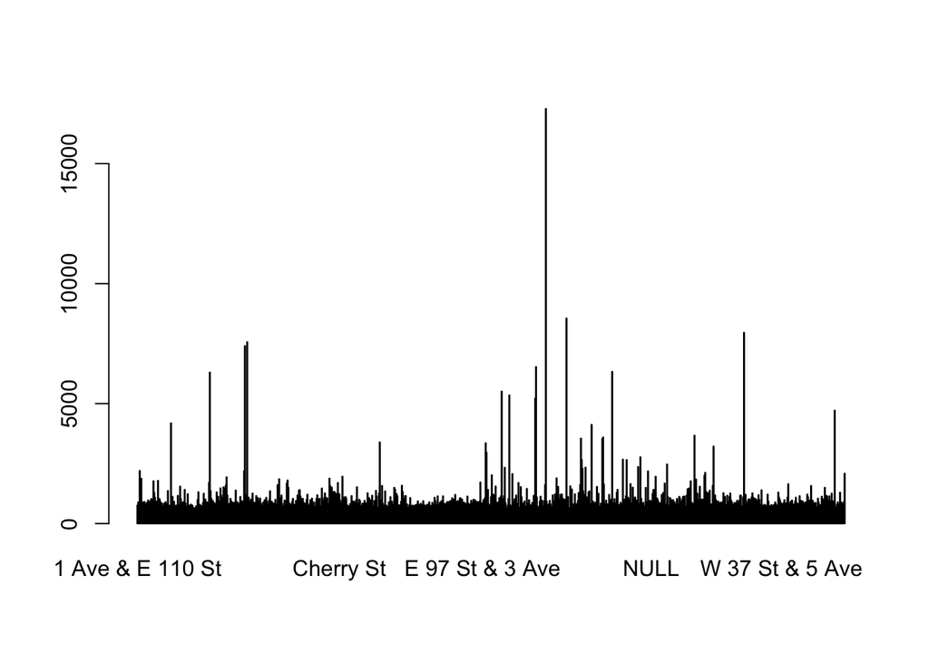

```r
barplot(tapply(citi_sample$tripduration, citi_sample$start.station.name, mean, na.rm = TRUE))
```

Some stations have significantly higher trip duration than the expected average of 976.6982381 seconds. This may signal that at some of these stations bikes are being lost or possibly not returned.

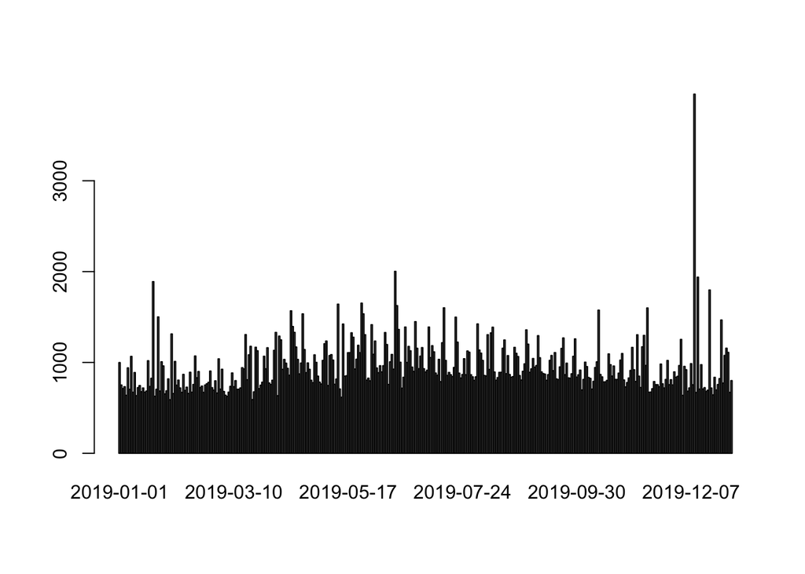

```r
barplot(tapply(citi_sample$tripduration, citi_sample$starttime, mean, na.rm = TRUE))
```

It seems that regardless of month the average trip durations vary around the same level. The number of trips may change, but trip duration is relatively consistent.

## Part 2: Identifying Patterns in The Ride History Data

Illustrating patterns in the data using visualizations

**Questions:** - Does ridership pattern differ between weekdays and weekends?

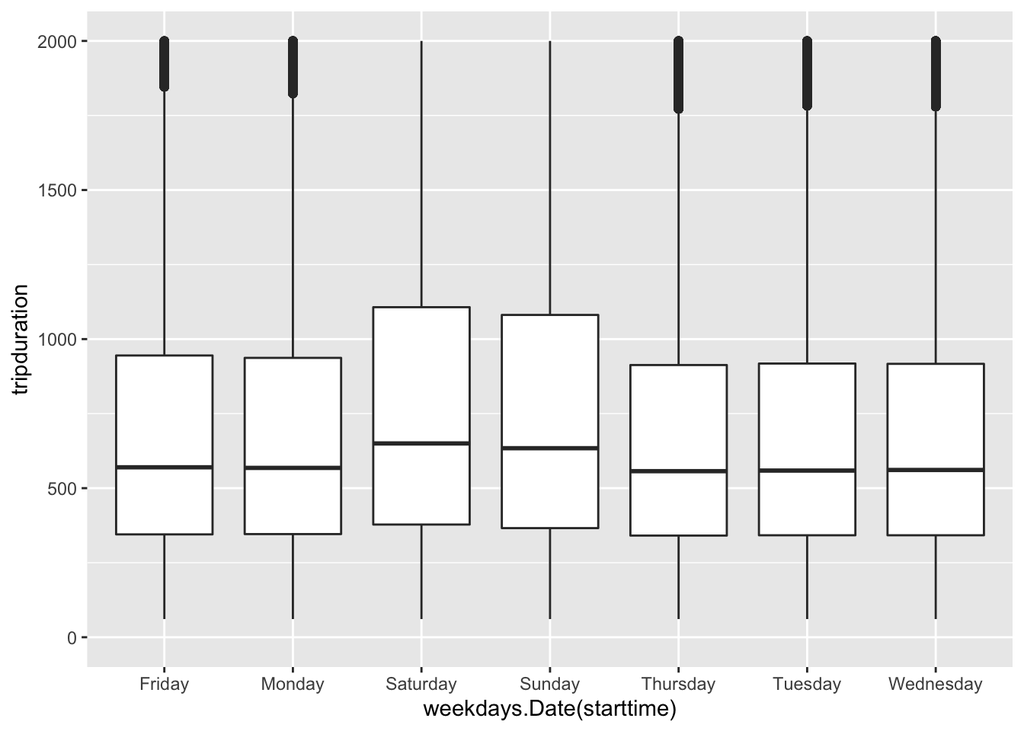

```r
ggplot(data = citi_sample, aes(x = weekdays.Date(starttime), y = tripduration)) + geom_boxplot() + ylim(0,2000)
```

From this data, we can see that the average trip duration on weekends (Saturday and Sunday) are slightly longer than those on weekdays. This is likely due to the fact that trips on weekends are likely for leisure and may be a little longer, while on weekdays more users may be using the bikes for commuting to work where time and being quick is more important.

- Do certain user types (customer vs. subscriber) have different trip duration

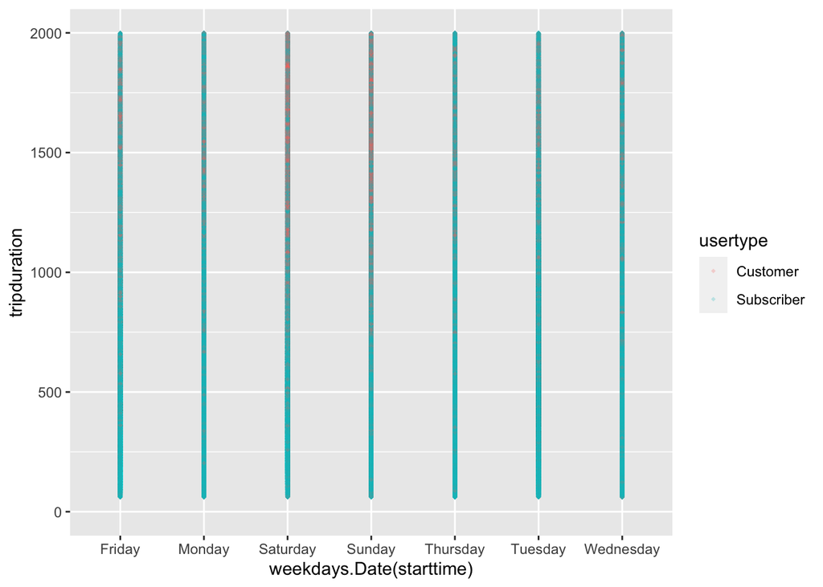

```r
ggplot(data=citi_sample, aes(x=weekdays.Date(starttime), y=tripduration, colour=usertype)) + geom_point(size=1, alpha=0.25, shape=18) + ylim(0,2000)
```

From this data, we can see that on average, customers are less likely to take a Citibike for trips with short trip duration than subscribers. This is likely because subscribers are using Citibikes for shorter commutes as well because they don’t have to pay for each trip individually (no marginal cost for each additional trip).

- Do certain genders (male vs. female) have different trip duration

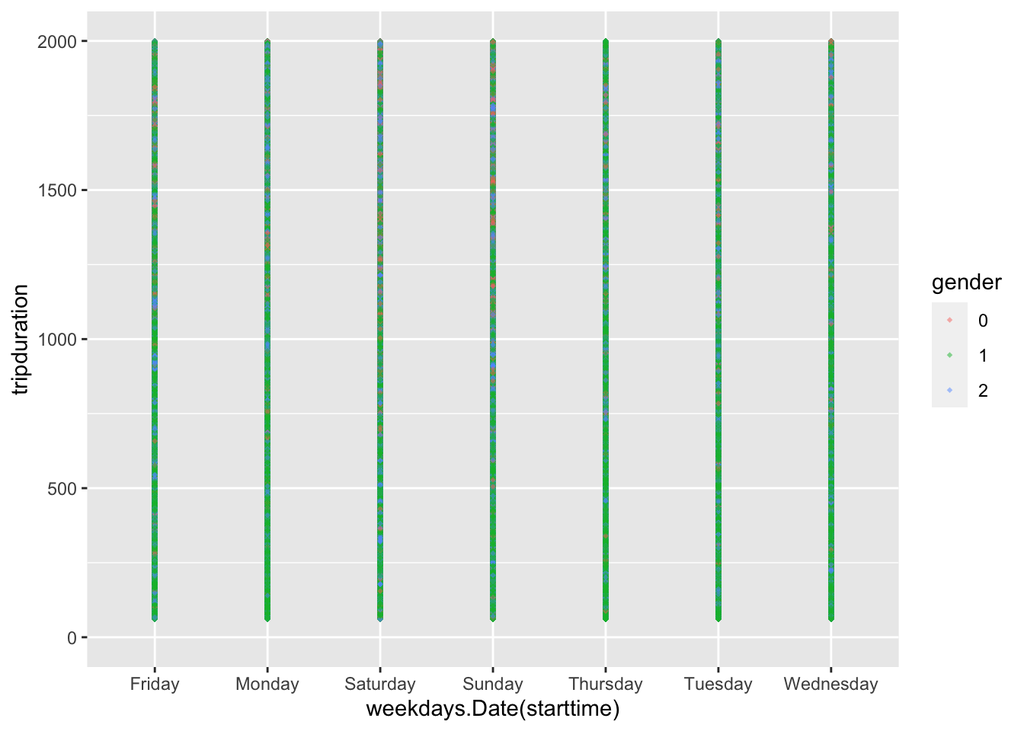

```r
ggplot(data=citi_sample, aes(weekdays.Date(starttime), y=tripduration, colour=gender)) + geom_point(size=1, alpha=0.5, shape=18) + ylim(0,2000)
```

It seems that gender has no effect on how long trip duration is. On average their are more males, but gender is not having a large effect.

- Which months are most popular for CitiBike usage?

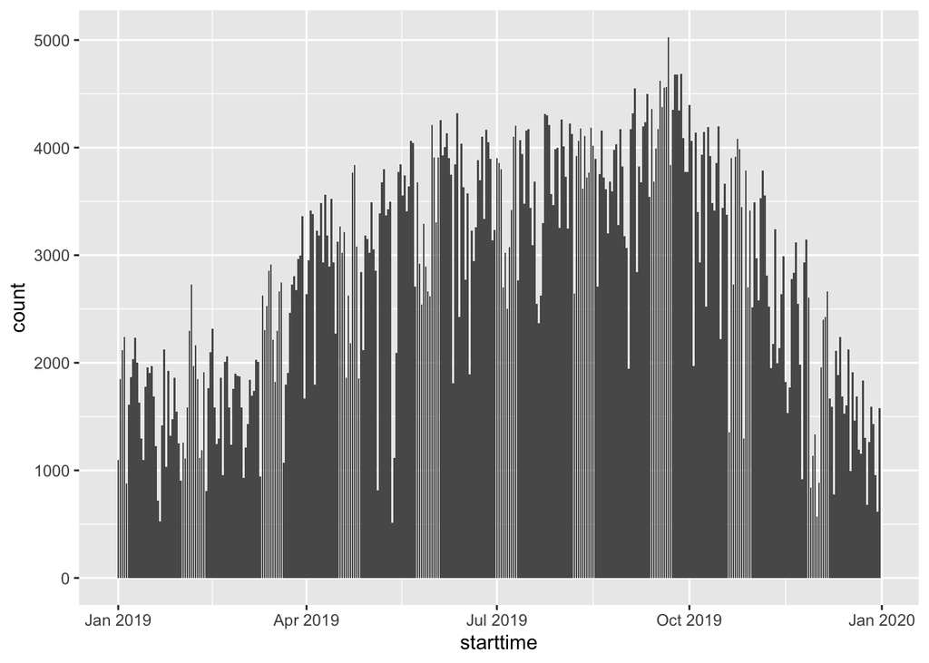

```r
ggplot(data=citi_sample, aes(x=starttime)) + geom_bar()
```

From this plot we can see that the winter months are much less popular for Citibike usage compared to the summer and fall. This makes sense, especially in New York as being able to ride a bike is very weather dependent (too hot or too cold would not be ideal).

- Which age groups are most likely to use CitiBikes?

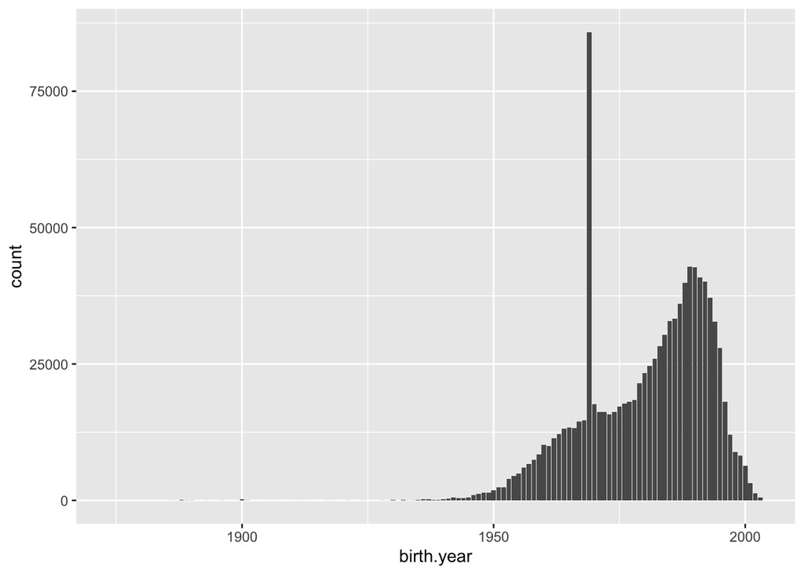

```r
ggplot(data=citi_sample, aes(x=birth.year)) + geom_bar()
```

From this bar plot we can see that most riders are born around 1990. However their seems to be a large group of riders (outlier) born around 1970. This shows that most riders are aged around 30 years old with a highly dedicated group of riders around 50 years old.

- Are certain stations more popular than others?

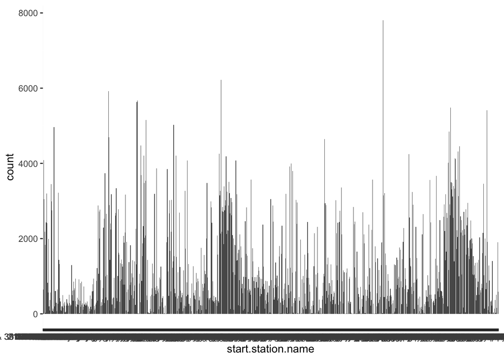

```r
ggplot(data=citi_sample, aes(x=start.station.name)) + geom_bar()
```